# Modeling

Sravani Vadali

6/9/2017

# Outdoor Analysis

We first check if any of the variables in the outdoor table are missing values.

```r
sum(is.na(outdoortable$date))
```

```
## [1] 7020
```

```r
sum(is.na(outdoortable$trait_id))
```

```
## [1] 0
```

```r
sum(is.na(outdoortable$mean))
```

```
## [1] 0
```

```r
sum(is.na(outdoortable$variable_name))
```

```
## [1] 0
```

```r
sum(is.na(outdoortable$treatment_name))
```

```
## [1] 697039
```

Since $treatment\_name$ is missing 697039 values, it is not considered in any of the modeling part.

As $date$ is missing 7020 values, we create a new dataset, $outdata$ that does not consider those rows which have missing date entries.

```r
a = which(is.na(outdoortable$date))
outdata = outdoortable[-a,]
```

```r
model1 = lm(log(mean + 1) ~ variable_name + trait_id + date, data = outdata)
summary(model1)
```

```
##
## Call:
## lm(formula = log(mean + 1) ~ variable_name + trait_id + date,
##     data = outdata)
##
## Residuals:
##     Min      1Q  Median      3Q     Max
## -3.3731 -0.1438 -0.0651  0.1255  1.4007
##
## Coefficients:
##                                Estimate Std. Error t value Pr(>|t|)
## (Intercept)                  -3.487e+02  5.733e+00  -60.83   <2e-16 ***
## variable_namecanopy_height    4.049e+00  1.968e-03 2057.26   <2e-16 ***
## variable_nameemergence_count  3.231e+00  3.761e-03  859.00   <2e-16 ***
## variable_nameheight           3.682e+00  1.392e-03 2644.97   <2e-16 ***
## variable_nameleaf_length      6.052e+00  1.612e-02  375.49   <2e-16 ***
## variable_nameleaf_width       4.103e+00  1.612e-02  254.56   <2e-16 ***
## trait_id                      5.909e-08  9.545e-10   61.90   <2e-16 ***
## date                         -3.841e-09  2.993e-11 -128.33   <2e-16 ***
## ---
## Signif. codes:  0 '***' 0.001 '**' 0.01 '*' 0.05 '.' 0.1 ' ' 1
##
## Residual standard error: 0.2038 on 702222 degrees of freedom
## Multiple R-squared:  0.9464, Adjusted R-squared:  0.9464
## F-statistic: 1.772e+06 on 7 and 702222 DF,  p-value: < 2.2e-16
```

```r
summary(model1)$adj.r.squared
```

```
## [1] 0.9464145
```

Considering interaction terms, we get,

```r
model2 = lm(log(mean + 1) ~ variable_name * trait_id * date, data = outdata)
summary(model2)
```

```
##
## Call:
## lm(formula = log(mean + 1) ~ variable_name * trait_id * date,
##     data = outdata)
##
## Residuals:
##      Min       1Q   Median       3Q      Max
## -2.94326 -0.13485 -0.06192  0.12055  1.46013
##
## Coefficients: (7 not defined because of singularities)
##                                              Estimate Std. Error t value
## (Intercept)                                -1.695e+04  1.091e+03  -15.53
## variable_namecanopy_height                 -1.240e+07  2.504e+05  -49.53
## variable_nameemergence_count               -7.321e+08  1.637e+07  -44.71
## variable_nameheight                        -6.813e+05  1.156e+04  -58.93
## variable_nameleaf_length                    6.052e+00  1.403e-02  431.38
## variable_nameleaf_width                     4.103e+00  1.403e-02  292.46
## trait_id                                    2.825e-06  1.818e-07   15.54
## date                                        1.125e-05  7.398e-07   15.21
## variable_namecanopy_height:trait_id         2.067e-03  4.173e-05   49.52
## variable_nameemergence_count:trait_id       1.220e-01  2.729e-03   44.71
## variable_nameheight:trait_id                1.136e-04  1.929e-06   58.90
## variable_nameleaf_length:trait_id                  NA         NA      NA
## variable_nameleaf_width:trait_id                   NA         NA      NA
## variable_namecanopy_height:date             8.648e-03  1.703e-04   50.79
## variable_nameemergence_count:date           4.996e-01  1.117e-02   44.72
## variable_nameheight:date                   -2.933e-07  9.489e-09  -30.91
## variable_nameleaf_length:date                      NA         NA      NA
## variable_nameleaf_width:date                       NA         NA      NA
## trait_id:date                              -1.875e-15  1.233e-16  -15.21
## variable_namecanopy_height:trait_id:date   -1.441e-12  2.838e-14  -50.79
## variable_nameemergence_count:trait_id:date -8.326e-11  1.862e-12  -44.72
## variable_nameheight:trait_id:date                  NA         NA      NA
## variable_nameleaf_length:trait_id:date             NA         NA      NA
## variable_nameleaf_width:trait_id:date              NA         NA      NA
##                                            Pr(>|t|)
## (Intercept)                                  <2e-16 ***
## variable_namecanopy_height                   <2e-16 ***
## variable_nameemergence_count                 <2e-16 ***
## variable_nameheight                          <2e-16 ***
```

[output cut: 11 more lines]

```
## variable_nameheight:date                     <2e-16 ***
## variable_nameleaf_length:date                    NA
## variable_nameleaf_width:date                     NA
## trait_id:date                                <2e-16 ***
## variable_namecanopy_height:trait_id:date     <2e-16 ***
## variable_nameemergence_count:trait_id:date   <2e-16 ***
## variable_nameheight:trait_id:date                NA
## variable_nameleaf_length:trait_id:date           NA
## variable_nameleaf_width:trait_id:date            NA
## ---
## Signif. codes:  0 '***' 0.001 '**' 0.01 '*' 0.05 '.' 0.1 ' ' 1
##
## Residual standard error: 0.1774 on 702213 degrees of freedom
## Multiple R-squared:  0.9594, Adjusted R-squared:  0.9594
## F-statistic: 1.037e+06 on 16 and 702213 DF,  p-value: < 2.2e-16
```

```r
summary(model2)$adj.r.squared
```

```
## [1] 0.9593952
```

This has a higher $Adjusted R^2$ value of 0.9593952.

```r
model1b = lm(log((mean + 1)^2) ~ variable_name + trait_id + date, data = outdata)
model2b = lm(log((mean + 1)^2) ~ variable_name * trait_id * date, data = outdata)
summary(model1b)$adj.r.squared
```

```
## [1] 0.9464145
```

```r
summary(model2b)$adj.r.squared
```

```
## [1] 0.9593952
```

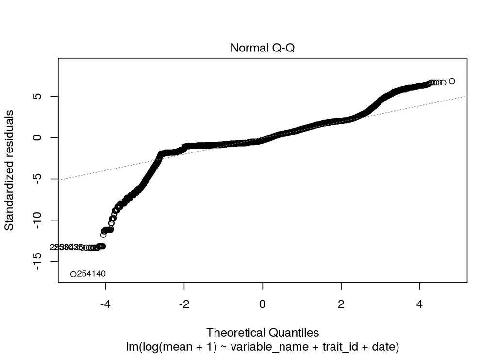

```r
plot(model1, which = c(2))
```

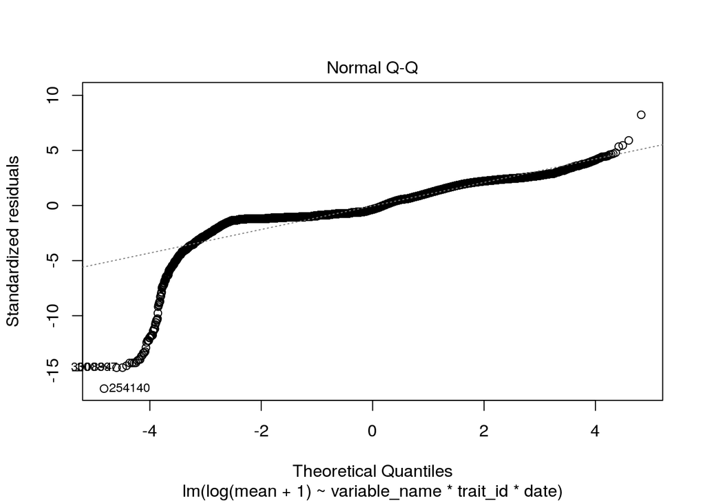

```r
plot(model2, which = c(2))
```

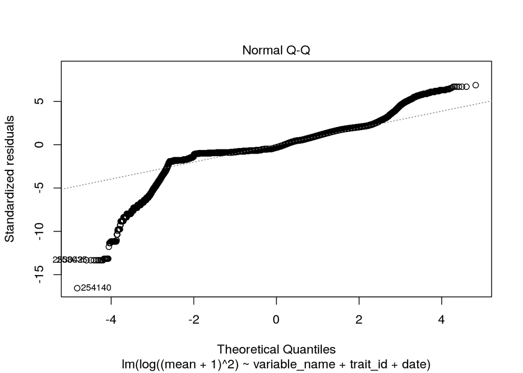

```r
plot(model1b, which = c(2))
```

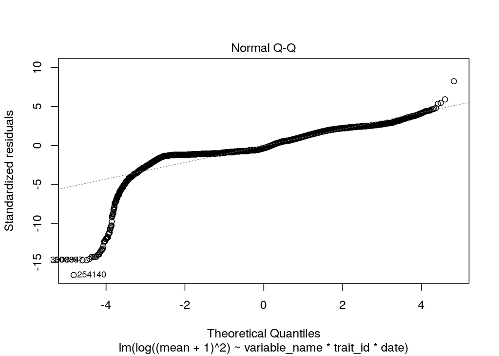

```r
plot(model2b, which = c(2))
```

All of the above models do not obey normal distribution.

```r
model3 = lm(log(mean + 1) ~ variable_name * date, data = outdata)
summary(model3)
```

```
##
## Call:
## lm(formula = log(mean + 1) ~ variable_name * date, data = outdata)
##
## Residuals:
##      Min       1Q   Median       3Q      Max
## -3.15186 -0.12888 -0.06295  0.11977  1.38659
##
## Coefficients: (2 not defined because of singularities)
##                                     Estimate Std. Error t value Pr(>|t|)
## (Intercept)                        6.374e+00  4.204e-02  151.62   <2e-16
## variable_namecanopy_height         1.935e+01  6.588e-01   29.38   <2e-16
## variable_nameemergence_count       4.691e+01  1.636e+00   28.68   <2e-16
## variable_nameheight               -3.847e+02  1.442e+00 -266.81   <2e-16
## variable_nameleaf_length           6.024e+00  1.537e-02  391.97   <2e-16
## variable_nameleaf_width            4.075e+00  1.537e-02  265.14   <2e-16
## date                              -4.213e-09  2.844e-11 -148.13   <2e-16
## variable_namecanopy_height:date   -1.044e-08  4.483e-10  -23.28   <2e-16
## variable_nameemergence_count:date -2.986e-08  1.117e-09  -26.73   <2e-16
## variable_nameheight:date           2.637e-07  9.790e-10  269.36   <2e-16
## variable_nameleaf_length:date             NA         NA      NA       NA
## variable_nameleaf_width:date              NA         NA      NA       NA
##
## (Intercept)                       ***
## variable_namecanopy_height        ***
## variable_nameemergence_count      ***
## variable_nameheight               ***
## variable_nameleaf_length          ***
## variable_nameleaf_width           ***
## date                              ***
## variable_namecanopy_height:date   ***
## variable_nameemergence_count:date ***
## variable_nameheight:date          ***
## variable_nameleaf_length:date
## variable_nameleaf_width:date
## ---
## Signif. codes:  0 '***' 0.001 '**' 0.01 '*' 0.05 '.' 0.1 ' ' 1
##
## Residual standard error: 0.1944 on 702220 degrees of freedom
## Multiple R-squared:  0.9512, Adjusted R-squared:  0.9512
## F-statistic: 1.522e+06 on 9 and 702220 DF,  p-value: < 2.2e-16
```

```r
summary(model3)$adj.r.squared
```

```
## [1] 0.9512484
```

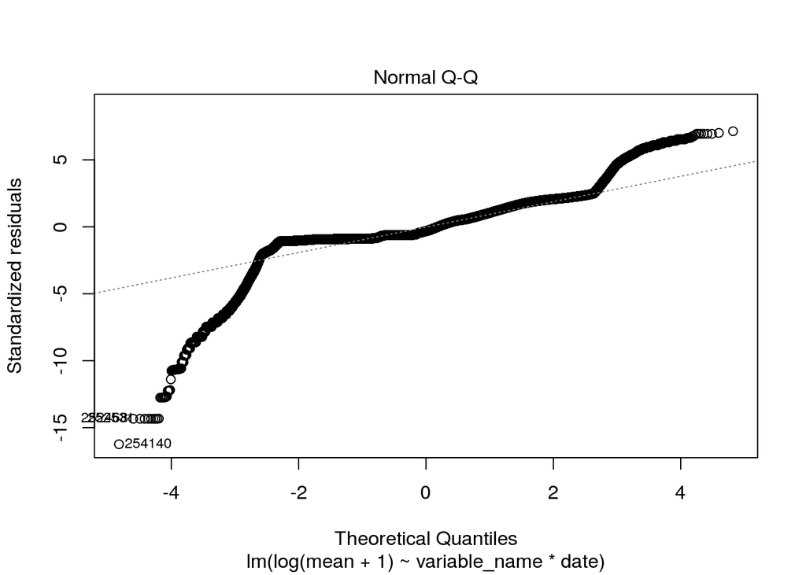

```r
plot(model3, which = c(2))
```

So, we next try to remove the influential points.